# The Ecological Footprint of North Pacific Hatchery Salmon

- Show All Code
- Hide All Code
- View Source

Author

Steven J.D. Martell

Published

April 17, 2026

Abstract

Approximately 5 billion hatchery salmon smolts are released into the North Pacific Ocean each year. This document estimates the cumulative ecological footprint of that cohort — the total prey biomass consumed across all ocean ages — using species-specific cohort simulation with empirical mortality, maturation, weight, and consumption parameters. Parameter uncertainty is propagated via Monte Carlo simulation (2,000 draws) to derive 95 % credible intervals on total and species-level prey consumption. Results are placed in context via comparisons to the Alaska Pollock commercial fishery and Alaskan Caribou grazing pressure.

## Background

Pacific salmon hatcheries in the North Pacific — operated primarily by Japan, Russia, the United States, and Canada — collectively release on the order of **5 billion smolts per year**. Once at sea, these fish feed actively on zooplankton, forage fish, and invertebrates for one to five years before returning to spawn. Their sheer abundance makes them a significant, yet often underappreciated, consumer of marine prey resources.

This analysis builds a simple **age-structured cohort model** for five species:

| Species | Typical ocean residence | Peak release volume |
| --- | --- | --- |
| Pink | 1 year | 1.5 billion |
| Chum | 3–5 years | 2.8 billion |
| Sockeye | 2–4 years | 300 million |
| Coho | 2–3 years | 200 million |
| Chinook | 2–5 years | 200 million |

For each species the model tracks numbers surviving natural mortality, the fraction that mature and leave the sea at each age, the standing biomass, and the annual prey consumption implied by species-specific consumption-to-biomass ratios ($Q/B$).

## Biological Parameters

### Hatchery Release Numbers

```r
releases <- data.frame(
  Species = c("Pink", "Chum", "Sockeye", "Coho", "Chinook"),
  Smolts_Released = c(1.5e9, 2.8e9, 300e6, 200e6, 200e6)
)

releases %>%
  mutate(Smolts_Released = comma(Smolts_Released)) %>%
  kable(
    col.names = c("Species", "Smolts Released"),
    align = c("l", "r"),
    caption = "Baseline annual hatchery smolt releases."
  ) %>%
  kable_styling(bootstrap_options = c("striped", "hover"), full_width = FALSE)
```

Baseline annual hatchery smolt releases.

| Species | Smolts Released |
| --- | --- |
| Pink | 1,500,000,000 |
| Chum | 2,800,000,000 |
| Sockeye | 300,000,000 |
| Coho | 200,000,000 |
| Chinook | 200,000,000 |

### Species-Specific Parameter Matrix

Each species × age combination has four parameters:

- **M** — instantaneous natural mortality rate (yr⁻¹)
- **m** — maturation probability (fraction exiting the ocean at this age)
- **Weight_kg** — mean individual body mass (kg)
- **Q_B** — consumption-to-biomass ratio (dimensionless, yr⁻¹)

```r
params <- tribble(
  ~Species,   ~Age, ~M,    ~m,   ~Weight_kg, ~Q_B,
  # Pink: 2-year life cycle, 100 % spawn at ocean age 2
  "Pink",     1,    3.22,  0.00,  0.15,       8.0,
  "Pink",     2,    0.22,  1.00,  1.50,       5.0,
  "Pink",     3,    0.00,  1.00,  0.00,       0.0,
  "Pink",     4,    0.00,  1.00,  0.00,       0.0,
  "Pink",     5,    0.00,  1.00,  0.00,       0.0,

  # Chum: ages 3–5
  "Chum",     1,    3.51,  0.00,  0.15,       8.0,
  "Chum",     2,    0.22,  0.00,  1.00,       5.0,
  "Chum",     3,    0.22,  0.30,  2.50,       4.0,
  "Chum",     4,    0.22,  0.60,  4.00,       3.5,
  "Chum",     5,    0.22,  1.00,  5.50,       3.0,

  # Sockeye: ages 2–4
  "Sockeye",  1,    3.22,  0.00,  0.20,       7.0,
  "Sockeye",  2,    0.22,  0.10,  1.20,       5.0,
  "Sockeye",  3,    0.22,  0.50,  2.50,       4.0,
  "Sockeye",  4,    0.22,  1.00,  3.50,       3.5,
  "Sockeye",  5,    0.00,  1.00,  0.00,       0.0,

  # Coho: usually return by ocean age 3
  "Coho",     1,    2.81,  0.00,  0.30,       7.0,
  "Coho",     2,    0.22,  0.10,  1.50,       5.0,
  "Coho",     3,    0.22,  1.00,  3.50,       4.0,
  "Coho",     4,    0.00,  1.00,  0.00,       0.0,
  "Coho",     5,    0.00,  1.00,  0.00,       0.0,

  # Chinook: largest body size, latest maturation
  "Chinook",  1,    3.91,  0.00,  0.20,       7.0,
  "Chinook",  2,    0.22,  0.05,  1.50,       5.0,
  "Chinook",  3,    0.22,  0.20,  4.00,       4.0,
  "Chinook",  4,    0.22,  0.50,  7.00,       3.5,
  "Chinook",  5,    0.22,  1.00, 10.00,       3.0
)

params %>%
  kable(
    col.names = c("Species", "Ocean Age", "M (yr⁻¹)", "Maturation (m)",
                  "Weight (kg)", "Q/B"),
    digits = 2,
    caption = "Species- and age-specific biological parameters used in the cohort simulation."
  ) %>%
  kable_styling(bootstrap_options = c("striped", "hover", "condensed"), full_width = FALSE) %>%
  column_spec(1, bold = TRUE) %>%
  collapse_rows(columns = 1, valign = "top")
```

Species- and age-specific biological parameters used in the cohort simulation.

| Species | Ocean Age | M (yr⁻¹) | Maturation (m) | Weight (kg) | Q/B |
| --- | --- | --- | --- | --- | --- |
| Pink | 1 | 3.22 | 0.00 | 0.15 | 8.0 |
|  | 2 | 0.22 | 1.00 | 1.50 | 5.0 |
|  | 3 | 0.00 | 1.00 | 0.00 | 0.0 |
|  | 4 | 0.00 | 1.00 | 0.00 | 0.0 |
|  | 5 | 0.00 | 1.00 | 0.00 | 0.0 |
| Chum | 1 | 3.51 | 0.00 | 0.15 | 8.0 |
|  | 2 | 0.22 | 0.00 | 1.00 | 5.0 |
|  | 3 | 0.22 | 0.30 | 2.50 | 4.0 |
|  | 4 | 0.22 | 0.60 | 4.00 | 3.5 |
|  | 5 | 0.22 | 1.00 | 5.50 | 3.0 |
| Sockeye | 1 | 3.22 | 0.00 | 0.20 | 7.0 |
|  | 2 | 0.22 | 0.10 | 1.20 | 5.0 |
|  | 3 | 0.22 | 0.50 | 2.50 | 4.0 |
|  | 4 | 0.22 | 1.00 | 3.50 | 3.5 |
|  | 5 | 0.00 | 1.00 | 0.00 | 0.0 |
| Coho | 1 | 2.81 | 0.00 | 0.30 | 7.0 |
|  | 2 | 0.22 | 0.10 | 1.50 | 5.0 |
|  | 3 | 0.22 | 1.00 | 3.50 | 4.0 |
|  | 4 | 0.00 | 1.00 | 0.00 | 0.0 |
|  | 5 | 0.00 | 1.00 | 0.00 | 0.0 |
| Chinook | 1 | 3.91 | 0.00 | 0.20 | 7.0 |
|  | 2 | 0.22 | 0.05 | 1.50 | 5.0 |
|  | 3 | 0.22 | 0.20 | 4.00 | 4.0 |
|  | 4 | 0.22 | 0.50 | 7.00 | 3.5 |
|  | 5 | 0.22 | 1.00 | 10.00 | 3.0 |

## Cohort Simulation Model

### Model Structure

Numbers at sea follow standard cohort dynamics. Starting from the initial smolt release $N_1$, numbers at the next age are:

$$N_{a+1} = N_a \cdot e^{-M_a} \cdot (1 - m_a)
\tag{1}$$

where $M_a$ is the instantaneous natural mortality and $m_a$ is the fraction maturing (and leaving the ocean) at age $a$.

Standing biomass at each age is:

$$B_a = N_a \cdot W_a
\tag{2}$$

and annual prey consumption is:

$$C_a = B_a \cdot (Q/B)_a
\tag{3}$$

### Implementation

```r
run_species_model <- function(target_species) {
  sp_params <- params %>% filter(Species == target_species) %>% arrange(Age)
  sp_smolts <- releases %>% filter(Species == target_species) %>% pull(Smolts_Released)

  N_at_sea      <- numeric(5)
  Biomass_kg    <- numeric(5)
  Consumption_kg <- numeric(5)

  N_at_sea[1] <- sp_smolts

  for (a in 1:5) {
    Biomass_kg[a]     <- N_at_sea[a] * sp_params$Weight_kg[a]
    Consumption_kg[a] <- Biomass_kg[a] * sp_params$Q_B[a]

    if (a < 5) {
      N_at_sea[a + 1] <- N_at_sea[a] * exp(-sp_params$M[a]) * (1 - sp_params$m[a])
    }
  }

  sp_params %>%
    mutate(
      Numbers_Alive     = N_at_sea,
      Standing_Biomass_MT = Biomass_kg    / 1000,
      Prey_Consumed_MT  = Consumption_kg / 1000
    )
}

all_species_results <- map_dfr(releases$Species, run_species_model)
total_prey <- sum(all_species_results$Prey_Consumed_MT)
```

## Results

### Total Prey Consumption

```
Total estimated prey consumed by the hatchery cohort: 9,111,836 Metric Tons annually.
```

The entire hatchery cohort consumes an estimated **9,111,836 metric tons** of prey per year.

### Species Summary

```r
species_summary <- all_species_results %>%
  group_by(Species) %>%
  summarize(
    Smolts_Released  = max(Numbers_Alive[Age == 1]),
    Total_Biomass_MT = sum(Standing_Biomass_MT),
    Total_Prey_MT    = sum(Prey_Consumed_MT),
    .groups = "drop"
  ) %>%
  arrange(desc(Total_Prey_MT))

species_summary %>%
  mutate(
    Smolts_Released  = comma(round(Smolts_Released)),
    Total_Biomass_MT = comma(round(Total_Biomass_MT)),
    Total_Prey_MT    = comma(round(Total_Prey_MT))
  ) %>%
  kable(
    col.names = c("Species", "Smolts Released", "Standing Biomass (MT)",
                  "Prey Consumed (MT)"),
    align = c("l", "r", "r", "r"),
    caption = "Summary of modelled ecological footprint by species, sorted by prey consumption."
  ) %>%
  kable_styling(bootstrap_options = c("striped", "hover"), full_width = FALSE)
```

Summary of modelled ecological footprint by species, sorted by prey consumption.

| Species | Smolts Released | Standing Biomass (MT) | Prey Consumed (MT) |
| --- | --- | --- | --- |
| Chum | 2,800,000,000 | 889,248 | 5,178,596 |
| Pink | 1,500,000,000 | 314,899 | 2,249,494 |
| Coho | 200,000,000 | 108,500 | 632,063 |
| Sockeye | 300,000,000 | 108,186 | 621,049 |
| Chinook | 200,000,000 | 79,840 | 430,634 |

### Ecological Footprint by Age

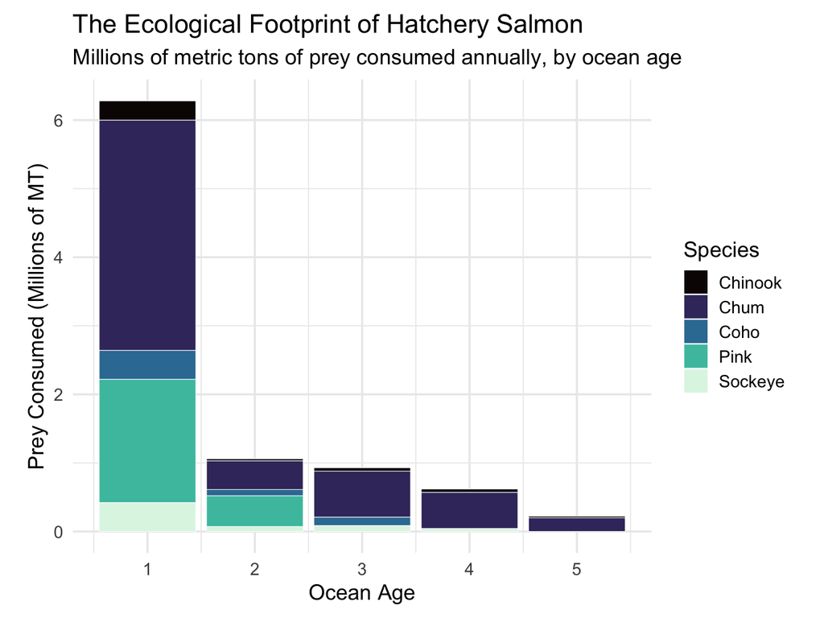

Figure 1: Annual prey consumption (millions of metric tons) by ocean age and species. Chum dominate by volume due to their high smolt releases and multi-year ocean residence.

```r
ggplot(
  all_species_results %>% filter(Prey_Consumed_MT > 0),
  aes(x = Age, y = Prey_Consumed_MT / 1e6, fill = Species)
) +
  geom_bar(stat = "identity", position = "stack", color = "white", linewidth = 0.2) +
  scale_fill_viridis_d(option = "mako") +
  scale_y_continuous(labels = comma) +
  labs(
    title    = "The Ecological Footprint of Hatchery Salmon",
    subtitle = "Millions of metric tons of prey consumed annually, by ocean age",
    x        = "Ocean Age",
    y        = "Prey Consumed (Millions of MT)",
    fill     = "Species"
  ) +
  theme_minimal(base_size = 15) +
  theme(
    legend.position = "right",
    plot.margin     = margin(10, 20, 10, 20)
  )
```

Ocean age 1 dominates consumption despite very high mortality at that stage, because smolt numbers entering the ocean are enormous. Chum’s multi-year residence and 2.8 billion smolt releases give them the largest cumulative footprint (Figure 1).

## Ecological Scale Comparisons

To put these numbers in perspective, the total hatchery prey consumption is compared to two well-known reference points.

```r
pollock_annual_harvest_mt <- 1.5e6   # U.S. Total Allowable Catch, Alaska Pollock
pollock_living_biomass_mt <- 5.5e6   # Estimated living biomass, Eastern Bering Sea
caribou_annual_forage_mt  <- 1.8     # Annual forage requirement, adult Alaskan Caribou

pollock_harvest_multiplier <- total_prey / pollock_annual_harvest_mt
pollock_biomass_multiplier <- total_prey / pollock_living_biomass_mt
caribou_equivalent         <- total_prey / caribou_annual_forage_mt
```

### Marine Comparison — Alaska Pollock

Alaska Pollock (*Gadus chalcogrammus*) supports the largest single-species fishery in the United States. The annual U.S. Total Allowable Catch is approximately **1.5 million MT**, and the estimated living biomass of the Eastern Bering Sea stock is roughly **5.5 million MT**.

**ImportantScale of hatchery consumption relative to pollock**

- Hatchery salmon consume **6.1 times** the entire annual U.S. commercial harvest of Alaska Pollock.
- They consume roughly **1.7 times** the *entire* living biomass of the Eastern Bering Sea pollock stock.

### Terrestrial Comparison — Alaskan Caribou

An adult Alaskan Caribou requires approximately 1.8 MT of forage per year. The hatchery cohort’s prey consumption is equivalent to the grazing pressure of:

**NoteCaribou equivalent**

**5,062,131 caribou** — more than twice the estimated global wild caribou/reindeer population.

## Implicit Marine Survival Rates

The model also implies species-specific marine survival rates — the fraction of released smolts that survive to spawn — derived from the same mortality and maturation parameters.

```r
survival_summary <- all_species_results %>%
  group_by(Species) %>%
  mutate(
    Mature_Returns = Numbers_Alive * exp(-M) * m
  ) %>%
  summarize(
    Smolts_Released     = max(Numbers_Alive[Age == 1]),
    Total_Returns       = sum(Mature_Returns),
    .groups = "drop"
  ) %>%
  mutate(
    Marine_Survival_Rate = Total_Returns / Smolts_Released,
    Survival_Percent     = percent(Marine_Survival_Rate, accuracy = 0.01)
  ) %>%
  arrange(desc(Marine_Survival_Rate)) %>%
  select(Species, Smolts_Released, Total_Returns, Survival_Percent)

survival_summary %>%
  mutate(across(where(is.numeric), ~comma(round(.)))) %>%
  kable(
    col.names = c("Species", "Smolts Released", "Estimated Returns", "Marine Survival"),
    align = c("l", "r", "r", "r"),
    caption = "Implicit marine survival rates derived from the cohort model parameters."
  ) %>%
  kable_styling(bootstrap_options = c("striped", "hover"), full_width = FALSE)
```

Implicit marine survival rates derived from the cohort model parameters.

| Species | Smolts Released | Estimated Returns | Marine Survival |
| --- | --- | --- | --- |
| Coho | 200,000,000 | 7,945,670 | 3.97% |
| Pink | 1,500,000,000 | 48,097,028 | 3.21% |
| Sockeye | 300,000,000 | 7,223,691 | 2.41% |
| Chum | 2,800,000,000 | 44,067,979 | 1.57% |
| Chinook | 200,000,000 | 2,070,239 | 1.04% |

Survival rates are low for all species, reflecting the intense natural mortality experienced during the first ocean year — a common empirical pattern for hatchery-origin fish.

## Uncertainty Analysis

The deterministic model uses fixed point estimates for all biological parameters. In practice, natural mortality ($M$), maturation schedules ($m$), body weight ($W$), and consumption-to-biomass ratios ($Q/B$) all carry meaningful uncertainty. Here we propagate that uncertainty via **Monte Carlo simulation** (2,000 draws), perturbing each parameter independently according to assumed coefficient of variation (CV):

| Parameter | Distribution | CV assumed |
| --- | --- | --- |
| $M$ (natural mortality) | Log-normal | 25 % |
| $m$ (maturation, 0 < m < 1) | Beta | 20 % |
| $W$ (body weight) | Log-normal | 15 % |
| $Q/B$ (consumption rate) | Log-normal | 30 % |
| Smolts released | Log-normal | 10 % |

Boundary values ($M = 0$, $m = 0$, $m = 1$) are held fixed — they represent structural life-history constraints, not uncertain estimates.

```r
set.seed(42)
n_sims <- 2000

# Draw from log-normal with specified mean and CV
rlnorm_cv <- function(n, mu, cv) {
  sigma2 <- log(1 + cv^2)
  rlnorm(n, meanlog = log(mu) - sigma2 / 2, sdlog = sqrt(sigma2))
}

# Draw from beta parameterized by mean and CV
# Guard against boundary values (case_when evaluates all RHS before filtering)
rbeta_cv <- function(n, mu, cv) {
  if (mu <= 0) return(rep(0, n))
  if (mu >= 1) return(rep(1, n))
  var   <- min((mu * cv)^2, mu * (1 - mu) * 0.99)
  kappa <- mu * (1 - mu) / var - 1
  rbeta(n, mu * kappa, (1 - mu) * kappa)
}
```

```r
run_one_sim <- function(sim_id) {
  # Perturb smolt releases
  sim_releases <- releases %>%
    mutate(Smolts_Released = map_dbl(Smolts_Released, ~rlnorm_cv(1, .x, cv = 0.10)))

  # Perturb all parameters row-wise
  sim_params <- params %>%
    rowwise() %>%
    mutate(
      M_s  = if (M > 0)         rlnorm_cv(1, M,         cv = 0.25) else 0,
      W_s  = if (Weight_kg > 0) rlnorm_cv(1, Weight_kg, cv = 0.15) else 0,
      QB_s = if (Q_B > 0)       rlnorm_cv(1, Q_B,       cv = 0.30) else 0,
      m_s  = case_when(
        m == 0 ~ 0,
        m == 1 ~ 1,
        TRUE   ~ rbeta_cv(1, m, cv = 0.20)
      )
    ) %>%
    ungroup()

  # Cohort simulation per species; return species-level prey (MT)
  map_dfr(releases$Species, function(sp) {
    sp_p <- sim_params %>% filter(Species == sp) %>% arrange(Age)
    sp_N <- sim_releases %>% filter(Species == sp) %>% pull(Smolts_Released)

    N <- numeric(5); N[1] <- sp_N
    prey_mt <- numeric(5)
    for (a in 1:5) {
      prey_mt[a] <- N[a] * sp_p$W_s[a] * sp_p$QB_s[a] / 1000
      if (a < 5) N[a + 1] <- N[a] * exp(-sp_p$M_s[a]) * (1 - sp_p$m_s[a])
    }
    tibble(Species = sp, Prey_MT = sum(prey_mt))
  }) %>%
    mutate(Sim = sim_id)
}

mc_results <- map_dfr(seq_len(n_sims), run_one_sim)

mc_totals <- mc_results %>%
  group_by(Sim) %>%
  summarize(Total_Prey_MT = sum(Prey_MT), .groups = "drop")
```

### Distribution of Total Prey Consumption

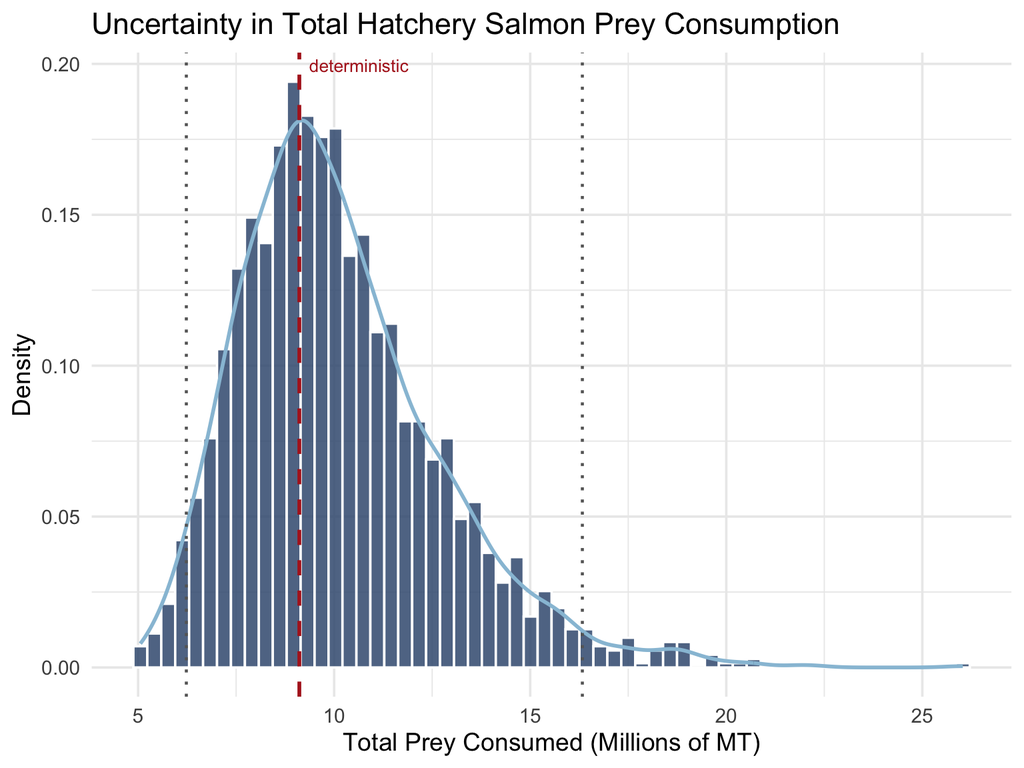

```r
q_total <- quantile(mc_totals$Total_Prey_MT, c(0.025, 0.50, 0.975))

ggplot(mc_totals, aes(x = Total_Prey_MT / 1e6)) +
  geom_histogram(
    aes(y = after_stat(density)),
    bins = 60, fill = "#3d5a80", color = "white", alpha = 0.85
  ) +
  geom_density(color = "#98c1d9", linewidth = 1) +
  geom_vline(xintercept = total_prey / 1e6, color = "firebrick", linewidth = 1,
             linetype = "dashed") +
  geom_vline(xintercept = q_total[c(1, 3)] / 1e6, color = "grey40",
             linetype = "dotted", linewidth = 0.8) +
  annotate("text", x = total_prey / 1e6, y = Inf,
           label = "  deterministic", color = "firebrick",
           hjust = 0, vjust = 1.5, size = 3.5) +
  scale_x_continuous(labels = comma) +
  labs(
    title = "Uncertainty in Total Hatchery Salmon Prey Consumption",
    x     = "Total Prey Consumed (Millions of MT)",
    y     = "Density"
  ) +
  theme_minimal(base_size = 14)
```

The 95 % credible interval spans **6–16 million MT** (median 10 million MT), confirming that the order-of-magnitude finding is robust across the assumed parameter uncertainty.

### Species-Level Uncertainty

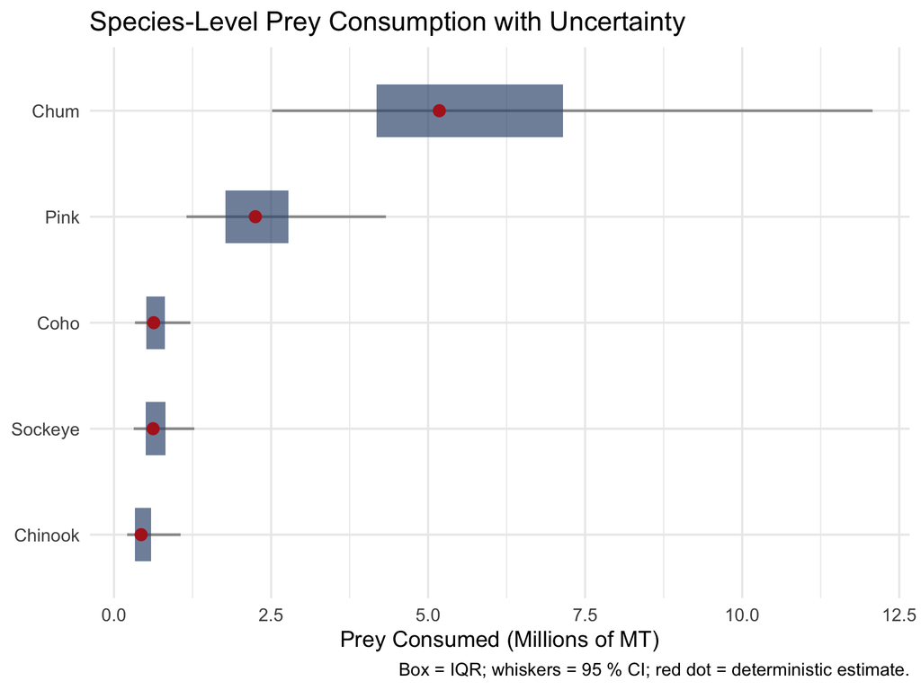

Figure 3: Species-level uncertainty in prey consumption. Boxes show the interquartile range; whiskers extend to the 2.5th and 97.5th percentiles. Dot is the deterministic estimate.

```r
mc_species_q <- mc_results %>%
  group_by(Species) %>%
  summarize(
    lo    = quantile(Prey_MT, 0.025),
    q25   = quantile(Prey_MT, 0.25),
    med   = quantile(Prey_MT, 0.50),
    q75   = quantile(Prey_MT, 0.75),
    hi    = quantile(Prey_MT, 0.975),
    .groups = "drop"
  )

det_species <- all_species_results %>%
  group_by(Species) %>%
  summarize(Prey_MT = sum(Prey_Consumed_MT), .groups = "drop")

mc_species_q <- left_join(mc_species_q, det_species, by = "Species") %>%
  mutate(Species = fct_reorder(Species, med))

ggplot(mc_species_q, aes(y = Species)) +
  geom_segment(aes(x = lo / 1e6, xend = hi / 1e6, yend = Species),
               color = "grey60", linewidth = 0.8) +
  geom_rect(aes(xmin = q25 / 1e6, xmax = q75 / 1e6,
                ymin = as.numeric(Species) - 0.25,
                ymax = as.numeric(Species) + 0.25),
            fill = "#3d5a80", alpha = 0.7) +
  geom_point(aes(x = Prey_MT / 1e6), color = "firebrick", size = 3) +
  scale_x_continuous(labels = comma) +
  labs(
    title = "Species-Level Prey Consumption with Uncertainty",
    x     = "Prey Consumed (Millions of MT)",
    y     = NULL,
    caption = "Box = IQR; whiskers = 95 % CI; red dot = deterministic estimate."
  ) +
  theme_minimal(base_size = 14)
```

```r
mc_species_q %>%
  arrange(desc(med)) %>%
  mutate(across(c(lo, q25, med, q75, hi, Prey_MT),
                ~ comma(round(. / 1e6, 2)))) %>%
  kable(
    col.names = c("Species", "2.5%", "25%", "Median", "75%", "97.5%",
                  "Deterministic"),
    align = c("l", rep("r", 6)),
    caption = "Species prey consumption (millions of MT): Monte Carlo quantiles and deterministic point estimate."
  ) %>%
  kable_styling(bootstrap_options = c("striped", "hover"), full_width = FALSE)
```

Table 1: Species prey consumption (millions of MT): Monte Carlo quantiles and deterministic point estimate.

| Species | 2.5% | 25% | Median | 75% | 97.5% | Deterministic |
| --- | --- | --- | --- | --- | --- | --- |
| Chum | 2.52 | 4.18 | 5.47 | 7.150 | 12.08 | 5.18 |
| Pink | 1.15 | 1.77 | 2.24 | 2.780 | 4.33 | 2.25 |
| Coho | 0.33 | 0.51 | 0.64 | 0.810 | 1.21 | 0.63 |
| Sockeye | 0.31 | 0.50 | 0.64 | 0.820 | 1.28 | 0.62 |
| Chinook | 0.21 | 0.34 | 0.44 | 0.590 | 1.06 | 0.43 |

## Discussion & Caveats

This is a **back-of-the-envelope cohort model**, not a full ecosystem assessment. Key simplifying assumptions include:

1. **Static parameters** — $M$, $m$, $W$, and $Q/B$ are fixed across years and do not respond to density-dependence, climate variability, or ocean conditions.
2. **No spatial structure** — the model does not distinguish feeding areas, migration corridors, or overlap with wild salmon.
3. **$Q/B$ values** — drawn from Ecopath-style literature estimates; the 30 % CV assumed here is likely conservative — true uncertainty may be larger.
4. **No wild salmon** — only hatchery releases are included; wild-origin fish add additional, unquantified consumption.
5. **Single cohort** — the model represents one annual cohort. Multiple overlapping cohorts (especially for longer-lived Chinook and Chum) would compound the total.
6. **Independent parameter draws** — the Monte Carlo treats each parameter as independent. In reality, $M$ and $Q/B$ are often positively correlated (fast-living species eat more and die faster), which could widen the joint uncertainty.

## References

Consumption-to-biomass ratios and natural mortality values are broadly consistent with published Ecopath models for the Northeast Pacific:

- Aydin, K.Y., Lapko, V.V., Radchenko, V.I., & Livingston, P.A. (2002). *A comparison of eastern and western Bering Sea shelf and slope ecosystems through the use of mass-balance food web models.* NOAA Technical Memorandum NMFS-AFSC-130.
- Christensen, V., & Walters, C.J. (2004). Ecopath with Ecosim: methods, capabilities and limitations. *Ecological Modelling*, 172(2–4), 109–139.
- Ruggerone, G.T., & Irvine, J.R. (2018). Numbers and biomass of natural- and hatchery-origin Pacific salmon, year classes 1980–2015, in the North Pacific Ocean. *Marine and Coastal Fisheries*, 10(2), 152–168.